# Workshop 4 Worksheet

## Learning outcomes

By the end of the session, you should be familiar with:

- running logistic regression in JASP
- the interpretation of logistic regression coefficients
- sub-setting/filtering data in JASP
- recoding/dichotomising a variable in JASP

## Intro

This workshop introduces another type of regression analysis: **binary/binomial** “**logistic”** **or** **”logit” regression**. Binary logistic regression allows us to model dependent (”response”, “outcome”) $y$ variables that are not measured on a continuous numeric scale, but instead on a *simple dichotomous* scale that allows only two values (e.g. “**1**”/“0”; “**Yes**”/“No”; “**True**”/“False”; “**Present**”/“Abstent”; “**Success**”/“Failure”; “**Agree**”/“Disagree”; “**Trusts**”/“Doesn’t trust”; “**Survived**”/“Didn’t survive”, etc.). Such a variable is called *dichotomous* because its two value options present a “dichotomy”, but it is also often referred to by other names: *binary* or *binomial* (because it can take only *two* mutually exclusive values), *indicator* (because it “indicates” membership in a category - usually the category with the “positive” logical connotation (i.e. “yes”, “true”, “survived”, “trusts”, etc.), coded as **1**) or “**dummy**” (from the word’s meaning of a **substitute** or a **proxy** - as in “crash-test dummy” as a substitute for a human) - to signal the variable’s role as a placeholder that indicates the presence (typically coded as 1) or absence (coded as 0) of a specific qualitative characteristic.

Modelling such a variable using the *linear regression* approach from Workshop 3 is likely to result in inaccurate coefficients, because linear regression assumes a theoretically unbounded continuous numeric scale of measurement; when it encounters a *binary* outcome variable, it assumes that we only observed two values (0 and 1) on this unbound scale, but that the scale nevertheless exists in theory and other values could have been observed if we collected more data. But, in fact, we know that no other values are theoretically possible.

Nevertheless, we can *generalise* the logic of linear regression to make it applicable to *dichotomous* dependent variables. In fact, the method we learn about today - *binary/binomial logistic regression* - is an elementary case of a broader category of statistical models called *generalised linear models (GLMs)*. GLMs can be thought of as a two-stage modelling approach, in which we first model the response variable using a **probability** distribution - such as the *binomial* distribution in our case -, and then we model the *parameter of the distribution* using a collection of predictors and a special form of multiple regression. This all sounds very technical and it does involve some complex mathematics, but **applying** *logistic regression* **in practice** will feel very similar to what we have done with *linear regression* before. The challenge will be in finding the simplest way to interpret the statistical results accurately and *meaningfully* given that the resulting regression coefficients refer to estimates on a mathematically **transformed scale** rather than the original scale of measurement of the variables as it was the case in linear regression. The **Advanced topics** readings assigned for this week outline these challenges for those who would like to gain a deeper understanding of the mathematics and mechanics of *logistic regression*; for the rest of us, Connelly, Gayle, and Lambert (2016) (on the reading list) provides a very approachable introduction to the major challenges, specifically for sociological analyses (see, specifically, the sections between *Parameter estimates in logistic regression models* and *The presentation of logistic regression results*).

In essence, with *binary logistic regression* we will attempt to **predict the *probability* that an observation falls into one of the two categories of a dichotomous dependent (outcome) variable** based on one or more independent (*predictor*, *explanatory*) variables. Observations are predicted to fall into whichever one of the two outcome categories is most probable for them *given the values* they have on the *independent* variable(s). Logistic modelling is thus often considered a *classification* method, especially in *machine learning* parlance.

## Exercise 4.1: Predict whether social trust at country level is above average

This exercise is primarily designed to introduce some new data management skills that may be useful in other contexts, and to connect with the data and analysis performed in Workshop 3. In Workshop 3 Worksheet - Exercise 3 we fit a *multiple* *linear regression* model of “social trust” measured as a percentage of a country’s population who answered that “people in general can be trusted” (as opposed to “one cannot be too careful”) on the standard binary “social trust” survey question as asked in the World Values Survey (`trust_pct`). We regressed that outcome on two variables: `inequality_s80s20` and `Region`.

What if our research question would ask not about the distribution of trust on a percentage scale, but about **the factors associated with whether the level of social trust in a country is *above average*?**In this case, our “quantity of interest” is different and requires us to use a different dependent/outcome variable: one that *dichotomises* the proportion of `trust_pct` into two outcome categories: “below average” and “above average”. We can easily transform our existing measurement of social trust to map it onto such a *binary* dichotomy because the `trust_pct` measurement contains more detailed information. For this reason, in actual research it is not good practice to transform variables in such a way as to *lose* information; instead, we would strive to find a modelling method that applies to the format of the variable that encompasses the most available information. For our didactic purposes, however, we will *dichotomise* the `trust_pct` variable to practice this useful data-transformation technique.

Let’s load the **Trust & Inequality** (`trust_inequality.dta`) dataset into JASP (which can be downloaded from https://cgmoreh.github.io/SOC2069-QUANT/Data/ if not yet downloaded to a local/OneDrive folder).

### Task 5.1.1: Dichotomise the `trust_pct` variable

In JASP we can create new variables by switching to the **Edit Data** menu tab and clicking on the green plus sign above the first empty column at the end of our dataset (there are other ways too, but this is one):

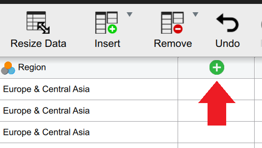

When clicked, a set of fields pop up where we can write in the name we want to give to the new variable (this is necessary) as well as other details. We will create a variable called `trust_d` to refer to “dyihotomised trust scale”. Once we enter the desired variable name into the **Name** field, we click enter and an empty variable is created. We can also add a label (Long name) and description, and for this exercise, under *Computed type* we will select to **compute** the values of the new variable **“with R code”.** This option is more flexible and allows us here to “cut” the `trust_pct` scale into two around the mean/average value.

For this, we need to know the mean value of `trust_pct` in the dataset. We can request a table of **Descriptive Statistics** for his, as we have done many times before, and find out that the mean value for `trust_pct` is **25.731**. Returning to the dataset window, we enter the following R code into the *Compute column definition* field:

```
cut(trust_pct, breaks = c(0, 25.731, 100))
```

Clicking the *Compute column* bar at the bottom of the field, the values are computed, and the window should look something like this:

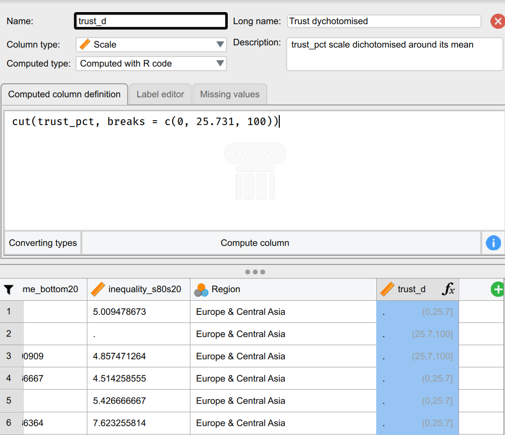

The only thing we need to know about the R code we just entered is that “cut” the `trust_pct` variable into sections around three break-points: the value 0, the mean value (25.731) and the value 100. Because 0 and 100 represent the absolute theoretical extreme points of the `trust_pct` scale (because it’s a percentage scale), the only actual “cut” in the dataset is made around the mean value. In R, the `c(...)` function simply means that we are “**c**ombining” the values enumerated into a list of numbers; we need to use it if we want to specify more than one value. If we only specify a single “break” value in the `cut(...)` function, then the `trust_pct` scale will be cut into that many sections - and that’s not what we want here.

We still need to do some changes to this newly minted variable. We can click on the *Label editor* tab, and there we will see the current values assigned automatically based on our “cutting” procedure: the first category are `trust_pct` values between **0** and **25.7** (inclusive), and the second category codes `trust_pct` values between **25.7** and **100**. We want some easier values and labels to use, so we’ll recode the first value as **0** and give it the label “Low trust”, and recode the second category as **1** and label it as “High trust”. Our window should now look something like this:

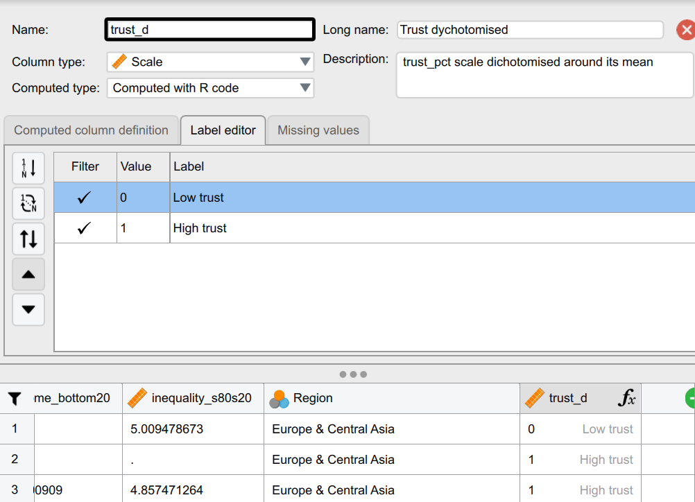

We can return to the *Analyses* menu tab now.

### Task 5.1.2. A scatter plot of `trust_d` by `inequality_s80s20`

We can check how the newly created variable is distributed by the values of our “inequality” measure by creating a scatter plot of their co-variation/co-relation. We have done scatter plots many times now. The result - simplified a bit - would look like this:

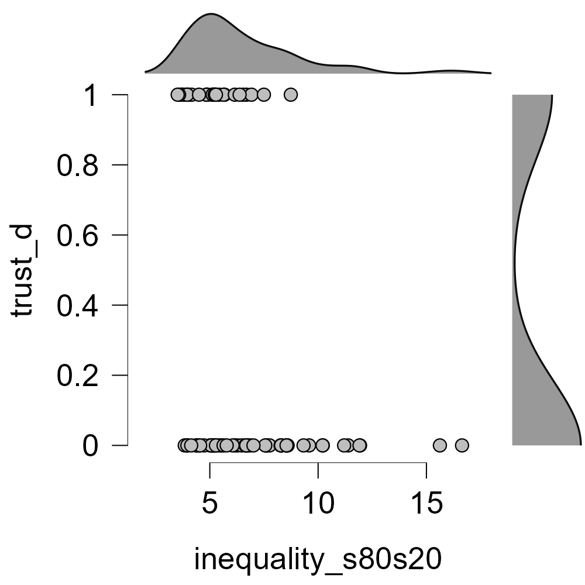

As expected, the `trust_d` variable only takes values of 0 and 1. This variable will be our new dependent variable that we want to model as a function of “inequality” and “Region”, as we have done in Workshop 3 Worksheet - Exercise 3 with the `trust_pct` variable.

### Task 5.1.3. Linear regression with dichotomous dependent variable

As a quick comparison with Workshop 3 Worksheet - Exercise 3, we can try to fit a linear regression using the new `trust_d` variable as dependent variable and `inequality_s80s20` and `Region` as the independent/predictor variables. Set it up in JASP, and the resulting output tables should look like this:

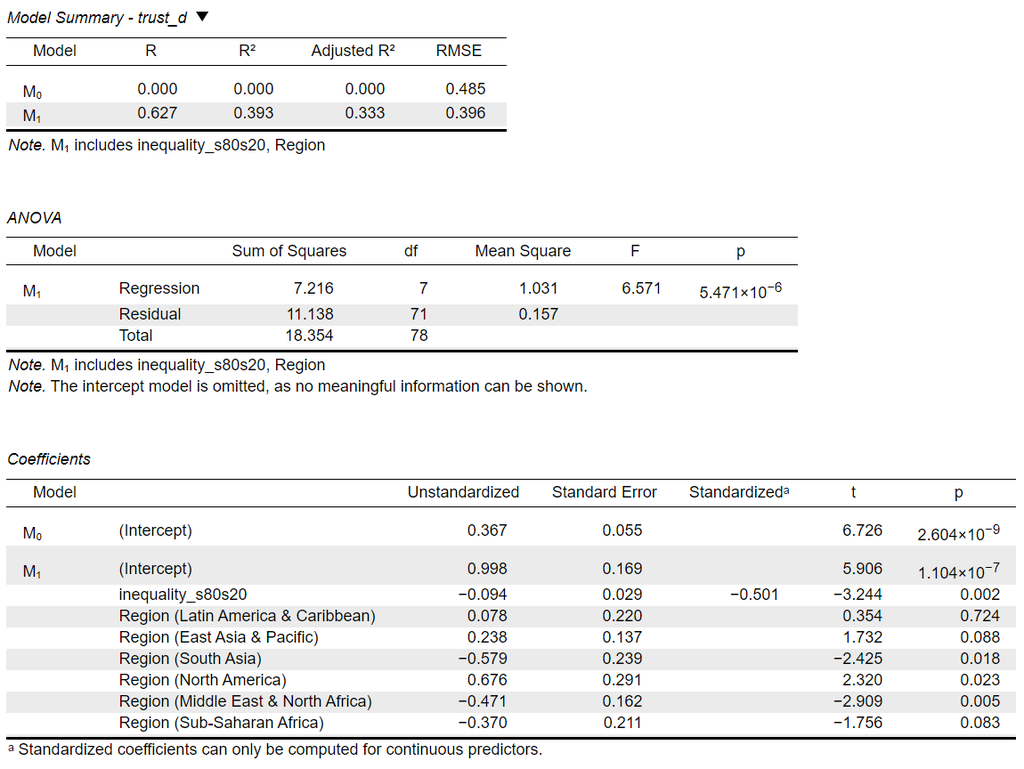

**Questions**

- Using the Answers to the Workshop 3 exercise sheet (you can find the sheet updated with answers on the website!), interpret the coefficients in the *Coefficients* table. Remember that the interpretation is exactly the same as in that previous exercise, because we have used a *linear regression model*. However, the **scale** of the dependent variable has changed, so that will effect the meaning of a **one-unit difference in the dependent variable**

### Task 5.1.4. Binary logistic regression in JASP

The main shortcoming of the linear model we fit in the previous task is, of course, that because our dependent variable only has two values, the *linear* model does not make very accurate predictions of the expected values of `trust_d`, which it assumes to be a continuous numeric variable. It makes predictions of values in between 0 and 1, and most unfortunately, of values below 0 and above 1, which cannot empirically exist. It is also likely to violate one of the core assumptions of *liner regression*, that the “errors” (i.e. the values of the dependent variables conditional on the predictor variables; e.g. the differences between the dots and the regression line on the scatter plot in the case of only one predictor) are “normally distributed”.

To account for these issues, we should choose a modelling method that fits an s-shaped *curve* instead of a *straight line*. Doing so, we force the model to restrict its estimates to between 0 and 1. The logistic regression model is the tool for this, and fitting it in JASP is straightforward, even through the interpretation of the coefficients not so much.

To run a binary logistic regression, navigate to through the following menu tab options:

$$\text{Regression} \longrightarrow \text{[Classical] Logistic regression}$$

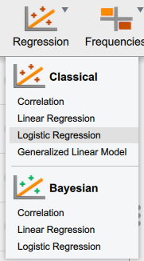

Inside the *Logistic regression* settings, we select our **dependent variable** (which this time must have only two distinct values/categories!), our continuous numeric *Covariate(s)* and any categorically coded *Factor(s*). Once we do this, we get the results in the outputs window to the right. before we look at the results, let’s also tick the box for “Odds ratios” under *Statistics* > *Coefficients* in the Logistic regression settings:

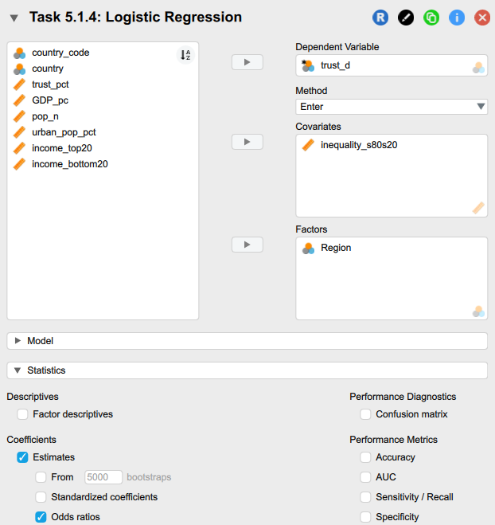

The resulting output should be:

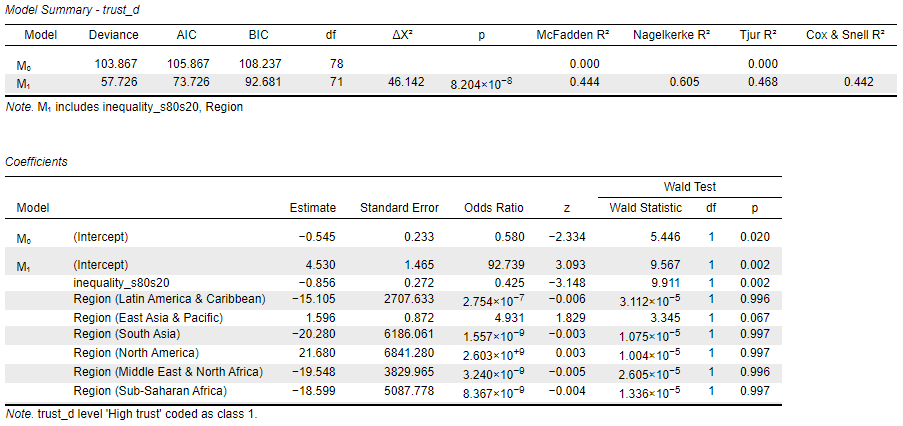

**Questions**

- What is the effect of a one-unit positive change on the `inequality_s80s20` scale **on the expected value** of `trust_d` ?
- What is the effect of a one-unit positive change on the `inequality_s80s20` scale **on the odds** of being a “high trust” country?

**Solutions**

A JASP file with the solutions to the exercises can be downloaded from HERE.

The **Odds Ratio** may sound more intuitive, but it’s equally difficult to grasp. A better solution would be to transform the dependent variable scale further to plain “probabilities”, which we are intuitively more familiar with because its values are at equal distances and run between 0 and 1 (just like a proportion, and similar to a percentage scale).

In JASP we can request visual outputs for the effects of the independent variables on the **probability** of the outcome by ticking the *Conditional estimates plots* option under **Inferential plots** under **Plots:**

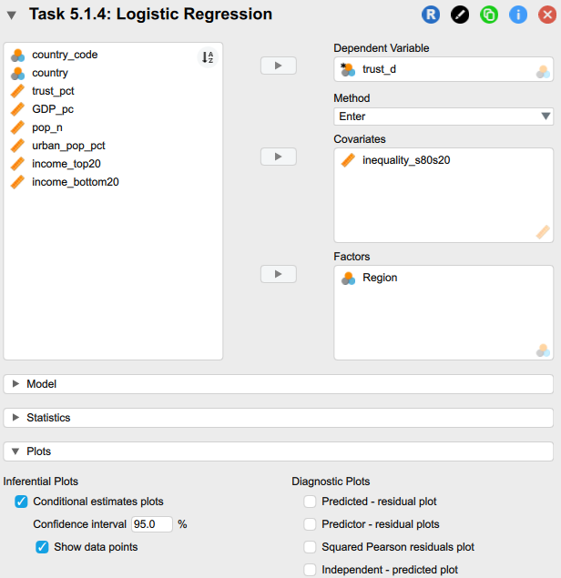

The resulting plots are visually more telling than the numbers in the regression output tables:

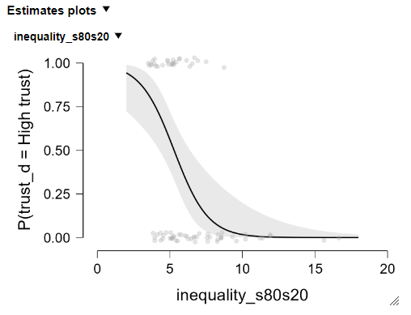

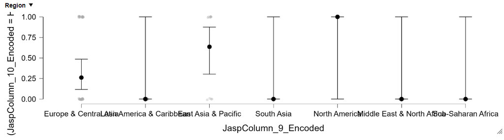

We find, for instance, that around the value of 7 on `inequality_s80s20`, the probability of being in the “High trust” category drops to under 0.25 (25%)

## Exercise 5.2 (take-home): Which of the assignment research questions could be addressed using a logistic regression model?

Let’s look again at the assignment research questions. Some of these questions imply a *dependent* variable which is measured as a *numeric scale* or at least a long-ish (e.g. 7-point +) *ordinal scale* in one of the surveys we will use for the assignment (ESS10, WVS7, EVS2017). Other questions imply *dependent* variables that are more strictly *categorical*, and as such, we cannot model them using linear regression. For those, we may be able to apply a logistic regression model.

It may be the case that the categorical variable of choice has more than two categories. While there are specific modelling methods for those types of variables, we are not covering them on this module. Instead, in Week 6 we will practice some further data transformation techniques to easily dichotomise such multi-categorical/multinomial variables.

In this exercise, explore the assignment dataset using the Variable search function on the website to identify any available variables for answering one/some of the questions below, and check how the implied dependent variable was measured:

1. Are religious people more satisfied with life?
2. Are older people more likely to see the death penalty as justifiable?
3. What factors are associated with opinions about future European Union enlargement among Europeans?
4. Is higher internet use associated with stronger anti-immigrant sentiments?
5. How does victimisation relate to trust in the police?
6. What factors are associated with belief in life after death?
7. Are government/public sector employees more inclined to perceive higher levels of corruption than those working in the private sector?

## References

Connelly, Roxanne, Vernon Gayle, and Paul S. Lambert. 2016. “Modelling Key Variables in Social Science Research: Introduction to the Special Section.” *Methodological Innovations* 9:2059799116637782. doi: 10.1177/2059799116637782.